# Einstaklingsverkefni 2 STÆ203

Ásgerður

2024-02-03

Ég les inn töfluna “spurningar_um_lifid_24.csv”

```r
dat <- read.table("spurningar_um_lifid_24.csv", sep = ";", header = T, dec = ",")
```

## Liður 1: Flokkabreyta

Veljið eina flokkabreytanna sem þið skoðuðuð í Hópverkefni 1. Teiknið graf sem lýsir úrtaksdreifingu hennar og lýsið útkomunni stuttlega með viðeigandi lýsistærðum.

```r
dat <- mutate(dat, is = factor(is))
```

Teiknum upp grafið fyrir flokkabreytuna **is**, í skemmtilegum litum

[output not shown]

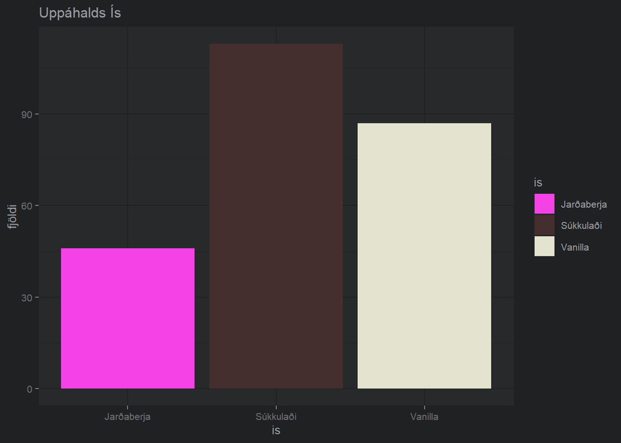

```r
ggplot(data = dat, aes(is, fill = is)) +
geom_bar() + labs(title = "Uppáhalds Ís", y = "fjöldi") + scale_fill_manual(values = c("#f542e6", "#452e2e", "#e3e3cf"))
```

Finnum fjölda gilda með *table* skipuninni

```r
table(dat$is)
```

```
##
## Jarðaberja  Súkkulaði    Vanilla
##         46        113         87
```

Sjáum úr bæði grafinu og töfluni að tíðasta gildið er *súkkulaðiís*.

## Liður 2: Talnabreyta

Veljið eina talnabreytanna sem þið skoðuðuð í Hópverkefni 1. Teiknið graf sem lýsir úrtaksdreifingu hennar og lýsið lögun hennar með viðeigandi lýsistærðum.

```r
dat$likamsraekt_dagar[dat$likamsraekt_dagar < 0|dat$likamsraekt_dagar>7] <- NA
```

Ég valdi að nota breytuna **likamsraekt_dagar**.

[output not shown]

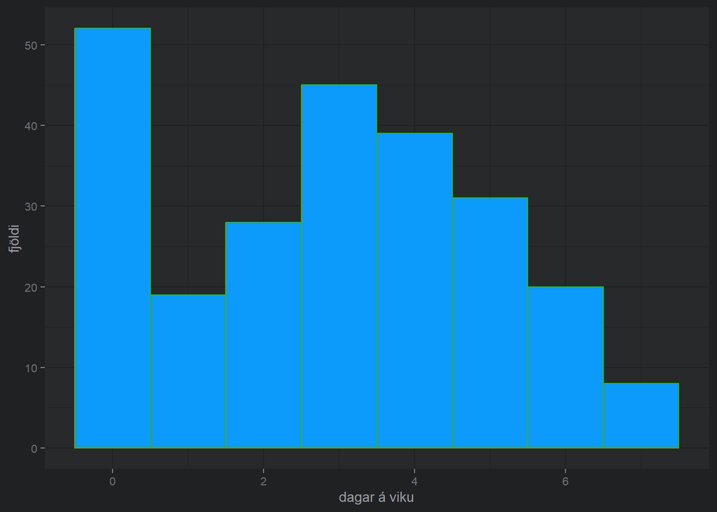

```r
ggplot(dat, aes(x = likamsraekt_dagar)) + geom_histogram(binwidth = 1, color= "#46ad0e", fill= "#0c9bfa")+ xlab("dagar á viku") + ylab("fjöldi")
```

```r
summary(dat$likamsraekt_dagar)
```

```
##    Min. 1st Qu.  Median    Mean 3rd Qu.    Max.    NA's
##   0.000   1.000   3.000   2.884   4.000   7.000       4
```

```r
sd(dat$likamsraekt_dagar, na.rm = T)
```

```
## [1] 2.075605
```

Sjáum að lægsta og hæsta gildi breytunar er *0* og *7*.

Meðaltalið er *2.884* og miðgildið er *3*.

Staðalfrávikið er *2.075605*.

```r
quantile(dat$likamsraekt_dagar, na.rm = T)
```

```
##   0%  25%  50%  75% 100%
##    0    1    3    4    7
```

Síðan sjáum við hér fyrir ofan *hlutfallsmörkin*.

## Liður 3: Samband talnabreytu og flokkabreytu.

Veljið eina talnabreytanna og eina flokkabreytanna sem þið skoðuðuð í Hópverkefni 1. Teiknið graf sem lýsir sambandi þessara tveggja breyta og lýsið útkomunni stuttlega með viðeigandi lýsistærðum. Hér gæti verið smart að setja upp litla töflu.

[output not shown]

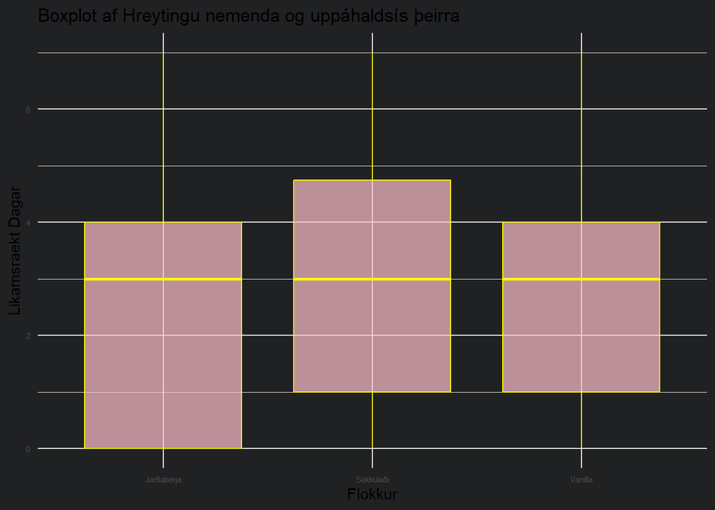

```r
ggplot(data = dat, aes(x = is, y = likamsraekt_dagar)) +
  geom_boxplot(fill = "pink", color = "yellow", alpha = 0.7) +
  theme_minimal() +
  labs(title = "Boxplot af Hreytingu nemenda og uppáhaldsís þeirra",
       x = "Flokkur",
       y = "Likamsraekt Dagar")
```

```r
library(dplyr)
library(knitr)

ice_cream_stats <- dat %>%
  group_by(is) %>%
  summarise(
    Median = median(likamsraekt_dagar, na.rm = TRUE),
    Lower_Quartile = quantile(likamsraekt_dagar, 0.25, na.rm = TRUE),
    Upper_Quartile = quantile(likamsraekt_dagar, 0.75, na.rm = TRUE),
    Mean = mean(likamsraekt_dagar, na.rm = TRUE),
    SD = sd(likamsraekt_dagar, na.rm = TRUE),
    Min = min(likamsraekt_dagar, na.rm = TRUE),
    Max = max(likamsraekt_dagar, na.rm = TRUE)
  )


print(ice_cream_stats)
```

```
## # A tibble: 3 × 8
##   is         Median Lower_Quartile Upper_Quartile  Mean    SD   Min   Max
##   <fct>       <dbl>          <dbl>          <dbl> <dbl> <dbl> <dbl> <dbl>
## 1 Jarðaberja      3              0           4     2.57  2.15     0     7
## 2 Súkkulaði       3              1           4.75  2.99  2.10     0     7
## 3 Vanilla         3              1           4     2.91  2.02     0     7
```

```r
kable(ice_cream_stats, format = "markdown",
      col.names = c("Ice Cream Category", "Median", "Lower Quartile", "Upper Quartile", "Mean", "SD", "Min", "Max"))
```

| Ice Cream Category | Median | Lower Quartile | Upper Quartile | Mean | SD | Min | Max |
| --- | --- | --- | --- | --- | --- | --- | --- |
| Jarðaberja | 3 | 0 | 4.00 | 2.568182 | 2.150151 | 0 | 7 |
| Súkkulaði | 3 | 1 | 4.75 | 2.986486 | 2.095948 | 0 | 7 |
| Vanilla | 3 | 1 | 4.00 | 2.913793 | 2.019105 | 0 | 7 |

Hér sést taflan með lýsistærðunum, flokkað eftir ísbragðtegundum.

## Liður 4: Samband tveggja talnabreyta

Veljið tvær talnabreytanna sem þið skoðuðuð í Hópverkefni 1. Teiknið graf sem lýsir sambandi þessara tveggja breyta og lýsið útkomunni stuttlega með viðeigandi lýsitærðum.

[output not shown]

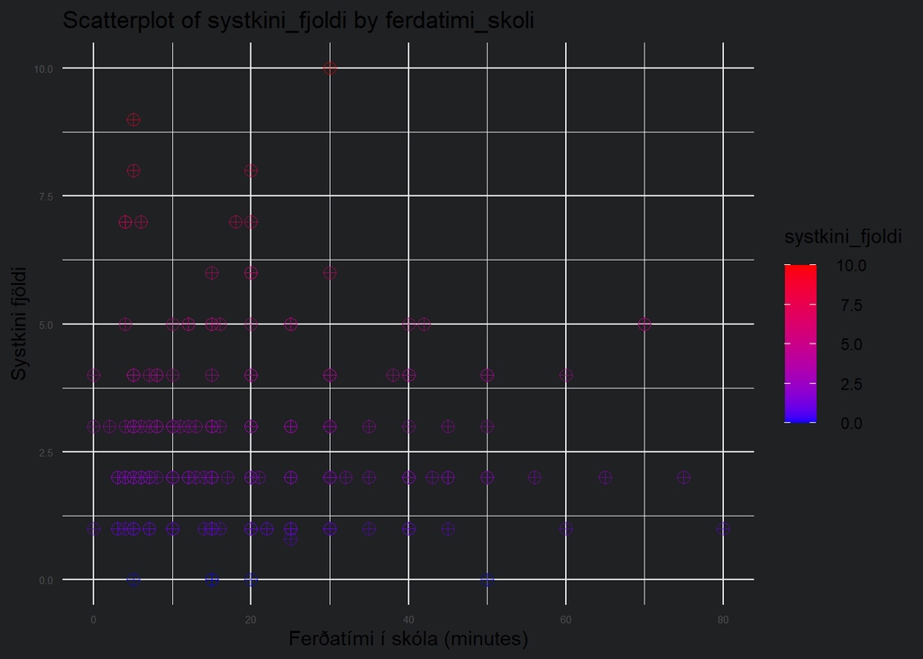

```r
ggplot(data = dat, aes(x = ferdatimi_skoli, y = systkini_fjoldi, color = systkini_fjoldi)) +
  geom_point(shape = 10, size = 3, alpha = 0.6) +

  scale_color_gradient(low = "blue", high = "red") +

  theme_minimal() +

  labs(title = "Scatterplot of systkini_fjoldi by ferdatimi_skoli",
       x = "Ferðatími í skóla (minutes)",
       y = "Systkini fjöldi")
```

```r
correlation <- cor(dat$ferdatimi_skoli, dat$systkini_fjoldi, use = "complete.obs")

model <- lm(systkini_fjoldi ~ ferdatimi_skoli, data = dat)
slope <- coef(model)[2]



residuals <- residuals(model)

statistics_table <- data.frame(
  "Statistic" = c("Correlation", "Slope" ),
  "Value" = c(correlation, slope)
)

print(statistics_table)
```

```
##                   Statistic        Value
##                 Correlation -0.010986380
## ferdatimi_skoli       Slope -0.001210063
```

Sjáum að fylgnin milli breytana er mjög lítil, og þær eru alveg ótengdar. Línulegt samband eir einnin nærri ekkert, svo breyturnar eru mjög ótengdar.

```r
summary(dat$systkini_fjoldi)
```

```
##    Min. 1st Qu.  Median    Mean 3rd Qu.    Max.
##   0.000   2.000   2.000   2.552   3.000  10.000
```

```r
summary(dat$ferdatimi_skoli)
```

```
##    Min. 1st Qu.  Median    Mean 3rd Qu.    Max.    NA's
##    0.00   10.00   16.00   20.02   25.00   80.00       4
```

Hér sjáum við svo nokka hluti um hvora breytu, meðaltal, miðgildi, min, max o.fl.